# ICT_LIS_661_Project_4

# Welcome to Project 4!

Before moving on, please make a copy of this file and rename it in a way that makes a clear distinction between the original file and the file you’ll eventually submit.

> Under the headers below, I’ll provide you with certain instructions, all of them formatted as blockquotes, like this paragraph is. Underneath each set of blockquoted instructions, you should write a response to any questions I ask and fill out any code chunks as I instruct you. At the very end of this document, I’ll provide instructions for *knitting* and submitting the `.Rmd` to Canvas.

## Project 4, Part 1: Your Dataset [6 points]

> In the code chunk below, please load the dataset into this document. (Keep in mind that you can—and may need to—install and load packages as part of this or any other code chunk). [1 point]

Part one was not that difficult, as we have been practicing this since the beginning of the class. At this point, it has become second nature to know how to read all types of data sets into R. The user can interpret the data set with ease using str() or summary(). I have loaded up all the packages that will be used in this project.

```r
library(here)
library(tidyverse)
library(infer)
library(moderndive)
library(nycflights13)
```

```r
library(ggplot2movies)
library(ggplot2)

## -----------------------------------------
## Loading in Data
## -----------------------------------------

game <- read_csv(here("project_4","imdb_video_game_rating.csv"))
```

```
## ──────────────────────────────────────────────────────── Delimiter: "," chr
## (5): title, year, genre, directors, plot dbl (2): ...1, rating
```

```r
str(game)
```

```
## spec_tbl_df [12,635 × 8] (S3: spec_tbl_df/tbl_df/tbl/data.frame)
##  $ ...1     : num [1:12635] 0 1 2 3 4 5 6 7 8 9 ...
##  $ title    : chr [1:12635] "The Last of Us: Part I" "Red Dead Redemption II" "The Witcher 3: Wild Hunt - Blood and Wine" "The Witcher 3: Wild Hunt" ...
##  $ year     : chr [1:12635] "2022" "2018" "2016" "2015" ...
##  $ genre    : chr [1:12635] "Action, Adventure, Drama" "Action, Adventure, Crime" "Action, Adventure, Drama" "Action, Adventure, Drama" ...
##  $ rating   : num [1:12635] 9.8 9.7 9.7 9.7 9.7 9.7 9.6 9.6 9.6 9.6 ...
##  $ votes    : num [1:12635] 601 36441 7610 26328 61103 ...
##  $ directors: chr [1:12635] "Matthew Gallant, Bruce Straley" "Missing" "Konrad Tomaszkiewicz" "Konrad Tomaszkiewicz" ...
##  $ plot     : chr [1:12635] "Experience the emotional storytelling and unforgettable characters in The Last of Us, winner of over 200 Game o"| __truncated__ "Amidst the decline of the Wild West at the turn of the 20th century, outlaw Arthur Morgan and his gang struggle"| __truncated__ "Geralt is …
##  - attr(*, "spec")=
##   .. cols(
##   ..   ...1 = col_double(),
##   ..   title = col_character(),
##   ..   year = col_character(),
##   ..   genre = col_character(),
##   ..   rating = col_double(),
##   ..   votes = col_number(),
##   ..   directors = col_character(),
##   ..   plot = col_character()
##   .. )
##  - attr(*, "problems")=<externalptr>
```

```r
class(game)
```

```
## [1] "spec_tbl_df" "tbl_df"      "tbl"         "data.frame"
```

```r
game
```

```
## # A tibble: 12,635 × 8
##     ...1 title                            year  genre rating votes direc…¹ plot
##    <dbl> <chr>                            <chr> <chr>  <dbl> <dbl> <chr>   <chr>
##  1     0 The Last of Us: Part I           2022  Acti…    9.8   601 Matthe… Expe…
##  2     1 Red Dead Redemption II           2018  Acti…    9.7 36441 Missing Amid…
##  3     2 The Witcher 3: Wild Hunt - Bloo… 2016  Acti…    9.7  7610 Konrad… Gera…
##  4     3 The Witcher 3: Wild Hunt         2015  Acti…    9.7 26328 Konrad… A mo…
##  5     4 The Last of Us                   2013  Acti…    9.7 61103 Neil D… In a…
##  6     5 Mass Effect: Legendary Edition   2021  Acti…    9.7  1628 Casey … A co…
##  7     6 God of War                       2018  Acti…    9.6 26507 Cory B… Afte…
##  8     7 Persona 5 Royal                  2019  Acti…    9.6  1214 Daiki … A gr…
##  9     8 The Legend of Zelda: Ocarina of… 1998  Acti…    9.6  9576 Eiji A… A yo…
## 10     9 Metal Gear Solid                 1998  Acti…    9.6 11809 Hideo … A cr…
## # … with 12,625 more rows, and abbreviated variable name ¹directors
```

> As needed, perform any data cleaning (including “tidying”) on the text in the code chunk below. [1 point]

```r
game$year = as.numeric(as.character(game$year))
game %>%
  na.omit()
```

```
## # A tibble: 12,532 × 8
##     ...1 title                             year genre rating votes direc…¹ plot
##    <dbl> <chr>                            <dbl> <chr>  <dbl> <dbl> <chr>   <chr>
##  1     0 The Last of Us: Part I            2022 Acti…    9.8   601 Matthe… Expe…
##  2     1 Red Dead Redemption II            2018 Acti…    9.7 36441 Missing Amid…
##  3     2 The Witcher 3: Wild Hunt - Bloo…  2016 Acti…    9.7  7610 Konrad… Gera…
##  4     3 The Witcher 3: Wild Hunt          2015 Acti…    9.7 26328 Konrad… A mo…
##  5     4 The Last of Us                    2013 Acti…    9.7 61103 Neil D… In a…
##  6     5 Mass Effect: Legendary Edition    2021 Acti…    9.7  1628 Casey … A co…
##  7     6 God of War                        2018 Acti…    9.6 26507 Cory B… Afte…
##  8     7 Persona 5 Royal                   2019 Acti…    9.6  1214 Daiki … A gr…
##  9     8 The Legend of Zelda: Ocarina of…  1998 Acti…    9.6  9576 Eiji A… A yo…
## 10     9 Metal Gear Solid                  1998 Acti…    9.6 11809 Hideo … A cr…
## # … with 12,522 more rows, and abbreviated variable name ¹directors
```

```r
game_fil <- game %>%
  select(-plot) %>%
  select(-directors) %>%
  select(-year) %>%
  select(-title) %>%
  select(-...1) %>%
  select(-votes)%>%
  filter(genre == c("Action, Adventure, Drama", "Action, Adventure, Fantasy"))
game_fil
```

```
## # A tibble: 747 × 2
##    genre                      rating
##    <chr>                       <dbl>
##  1 Action, Adventure, Drama      9.8
##  2 Action, Adventure, Drama      9.7
##  3 Action, Adventure, Drama      9.7
##  4 Action, Adventure, Drama      9.6
##  5 Action, Adventure, Fantasy    9.6
##  6 Action, Adventure, Drama      9.5
##  7 Action, Adventure, Drama      9.5
##  8 Action, Adventure, Fantasy    9.5
##  9 Action, Adventure, Drama      9.5
## 10 Action, Adventure, Fantasy    9.5
## # … with 737 more rows
```

```r
game_fil_reg <- game %>%
  select(-plot) %>%
  select(-directors) %>%
  select(-...1) %>%
  select(-votes)
game_fil_reg
```

```
## # A tibble: 12,635 × 4
##    title                                      year genre                  rating
##    <chr>                                     <dbl> <chr>                   <dbl>
##  1 The Last of Us: Part I                     2022 Action, Adventure, Dr…    9.8
##  2 Red Dead Redemption II                     2018 Action, Adventure, Cr…    9.7
##  3 The Witcher 3: Wild Hunt - Blood and Wine  2016 Action, Adventure, Dr…    9.7
##  4 The Witcher 3: Wild Hunt                   2015 Action, Adventure, Dr…    9.7
##  5 The Last of Us                             2013 Action, Adventure, Dr…    9.7
##  6 Mass Effect: Legendary Edition             2021 Action, Adventure, Sc…    9.7
##  7 God of War                                 2018 Action, Adventure, Dr…    9.6
##  8 Persona 5 Royal                            2019 Action, Adventure, Fa…    9.6
##  9 The Legend of Zelda: Ocarina of Time       1998 Action, Adventure, Fa…    9.6
## 10 Metal Gear Solid                           1998 Action, Adventure, Dr…    9.6
## # … with 12,625 more rows
```

```r
  game_fil_drama <- game_fil %>%
  filter(genre == "Action, Adventure, Drama")

  game_fil_fantasy <- game_fil %>%
   filter(genre == "Action, Adventure, Fantasy")
```

> In the code chunk below, write code to list the variables included in the dataset. Then, below the code chunk, list and explain 2-5 variables that you expect to explore with t-tests and regressions. [1 point]

In this step of the project, I used three forms of listing, as each one provides information in a different manner that may be desired by different researchers.

```r
str(game_fil)
```

```
## tibble [747 × 2] (S3: tbl_df/tbl/data.frame)
##  $ genre : chr [1:747] "Action, Adventure, Drama" "Action, Adventure, Drama" "Action, Adventure, Drama" "Action, Adventure, Drama" ...
##  $ rating: num [1:747] 9.8 9.7 9.7 9.6 9.6 9.5 9.5 9.5 9.5 9.5 ...
```

```r
ls(game_fil)
```

```
## [1] "genre"  "rating"
```

```r
summary(game_fil)
```

```
##     genre               rating
##  Length:747         Min.   :1.900
##  Class :character   1st Qu.:6.800
##  Mode  :character   Median :7.600
##                     Mean   :7.417
##                     3rd Qu.:8.200
##                     Max.   :9.800
```

> In the code chunk below, calculate descriptive statistics (including mean, median, variance, and standard deviation) for each of the variables you listed above. Then, below the code chunk, describe what those descriptive statistics tell you about those variables. [3 points]

In this part of the project, I made three different descriptive analyses. In the first method, I am focusing on the categorical variable “action, adventure, drama.” Within this method, a table is produced depicting the mean, median, standard deviation, and variance. In the second method, I am focusing on the categorical variable “action, adventure, fantasy.” Within this method, a table is produced depicting the mean, median, standard deviation, and variance. In the third method, I am focusing on all the categorical variables combined. Within this method, a table is produced depicting the mean, median, standard deviation, and variance overall.

```r
#Descriptive Stats for "Action, Adventure, Drama"
game_fil_drama_dis <- game_fil_drama %>%
  summarize(mean_rating = mean(rating), median_rating = median(rating), Variance_rating = var(rating), standard_deviation_rating = sd(rating))
game_fil_drama_dis
```

```
## # A tibble: 1 × 4
##   mean_rating median_rating Variance_rating standard_deviation_rating
##         <dbl>         <dbl>           <dbl>                     <dbl>
## 1        7.92           7.9           0.972                     0.986
```

```r
#Descriptive Stats for "Action, Adventure, Fantasy"
game_fil_fantasy_dis <- game_fil_fantasy %>%
  summarize(mean_rating = mean(rating), median_rating = median(rating), Variance_rating = var(rating), standard_deviation_rating = sd(rating))
game_fil_fantasy_dis
```

```
## # A tibble: 1 × 4
##   mean_rating median_rating Variance_rating standard_deviation_rating
##         <dbl>         <dbl>           <dbl>                     <dbl>
## 1        7.34           7.6            1.31                      1.14
```

```r
#All Descriptive Stats
game_fil_all_dis <- game_fil %>%
  summarize(mean_rating = mean(rating), median_rating = median(rating), Variance_rating = var(rating), standard_deviation_rating = sd(rating))
game_fil_all_dis
```

```
## # A tibble: 1 × 4
##   mean_rating median_rating Variance_rating standard_deviation_rating
##         <dbl>         <dbl>           <dbl>                     <dbl>
## 1        7.42           7.6            1.30                      1.14
```

## Project 3, Part 2: T-Test [6 points]

> For this part of the project, you will be carrying out a t-test. Please recall that the purpose of a t-test is to compare two means! Below, please describe a set of hypotheses (both null and alternative) related to this data that can be tested using a t-test. [2 points]

For my hypothesis I am focusing on genres of games and their ratings to see if there is any pattern.

### Hypotheses

H0: Genres have no effect on game ratings. HA: Genres affect game ratings.

### Data Analysis

> In the code chunk below, please carry out a t-test that will test the hypotheses listed above. Then, below the code chunk, summarize the results of this analysis. Make particular reference to relevant statistics, including t-value and p-value (statistical significance). [3 points]

```r
null_distribution <- game_fil %>%
  specify(formula = rating ~ genre) %>%
  hypothesize(null = "independence") %>%
  generate(reps = 1000, type = "permute") %>%
  calculate(stat = "diff in means", order = c("Action, Adventure, Drama", "Action, Adventure, Fantasy"))
 null_distribution
```

```
## Response: rating (numeric)
## Explanatory: genre (factor)
## Null Hypothesis: independence
## # A tibble: 1,000 × 2
##    replicate       stat
##        <int>      <dbl>
##  1         1 -0.0160
##  2         2  0.109
##  3         3 -0.0773
##  4         4 -0.185
##  5         5  0.0283
##  6         6  0.176
##  7         7 -0.0000775
##  8         8  0.175
##  9         9  0.115
## 10        10 -0.215
## # … with 990 more rows
```

```r
 obs_diff_means <- game_fil %>%
   specify(rating ~ genre) %>%
   calculate(stat = "diff in means", order = c("Action, Adventure, Drama", "Action, Adventure, Fantasy"))
 obs_diff_means
```

```
## Response: rating (numeric)
## Explanatory: genre (factor)
## # A tibble: 1 × 1
##    stat
##   <dbl>
## 1 0.588
```

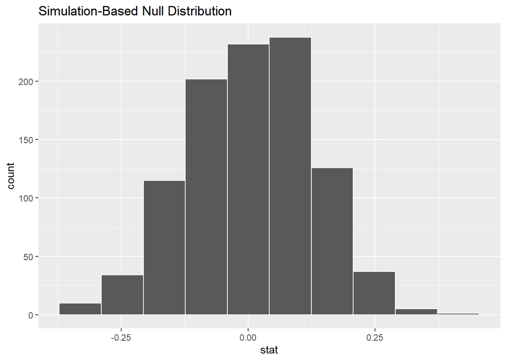

```r
 visualize(null_distribution, bins = 10)
```

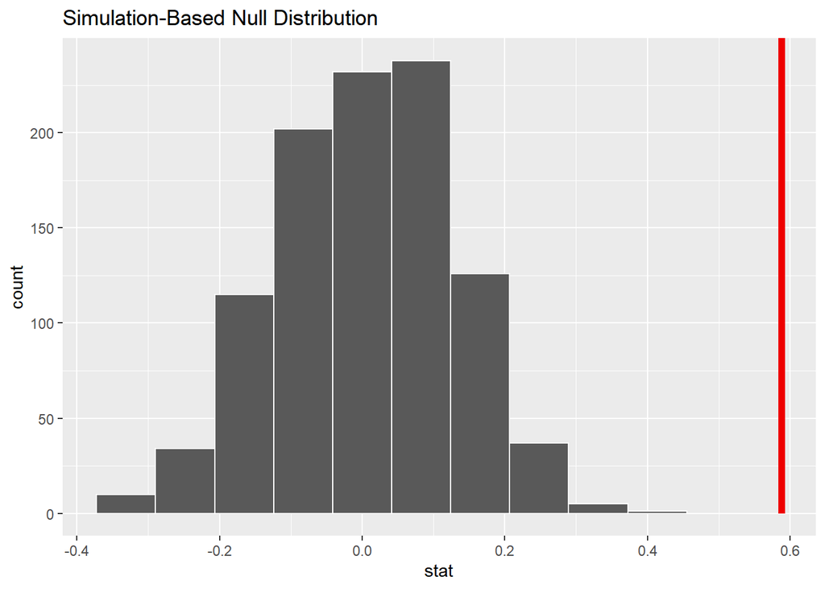

```r
visualize(null_distribution, bins = 10) +
  shade_p_value(obs_stat = obs_diff_means, direction = "right")
```

```r
null_distribution %>%
  get_p_value(obs_stat = obs_diff_means, direction = "right")
```

```
## # A tibble: 1 × 1
##   p_value
##     <dbl>
## 1       0
```

### Conclusions

> Below, interpret the results of this analysis (that is, describe what the results mean for your data). Please also discuss any practical implications of these results (that is, explain how people might wish to think or act differently based on these results). [1 points]

After looking at the results, I would reject the null hypothesis as my p-value is below the pre-specified level of a=.005. This would mean we would reject the idea that genres have no effect on game ratings. thus accepting the idea that genres affect game ratings overall. One theory that I have for why this result came to be is by looking at the observation count. When looking at the observations closely, I noticed that there are many more “action, adventure, and fantasy” observations than “action, adventure, and drama” observations in the DF.

## Project 3, Part 3: Regression [8 points]

> For this part of the project, you will be carrying out a regression. Please recall that the purpose of regression is to describe the relationship between two (or more) variables! Below, please describe a set of hypotheses (both null and alternative) related to this data that can be tested using regression. [2 points]

### Hypotheses

HO: Year of game has no affect on the rating. HA: Year of game has an affect on the rating.

### Data Analysis

> In the code chunk below, please carry out a regression that will test the hypotheses listed above. Then, below the code chunk, summarize the results of this analysis. Make particular reference to relevant statistics, including beta (coefficient), t-value and p-value (statistical significance). [4 points]

```r
#cor()
game_fil_reg %>% na.omit() %>%
  get_correlation(formula = year ~ rating)
```

```
## # A tibble: 1 × 1
##     cor
##   <dbl>
## 1 0.153
```

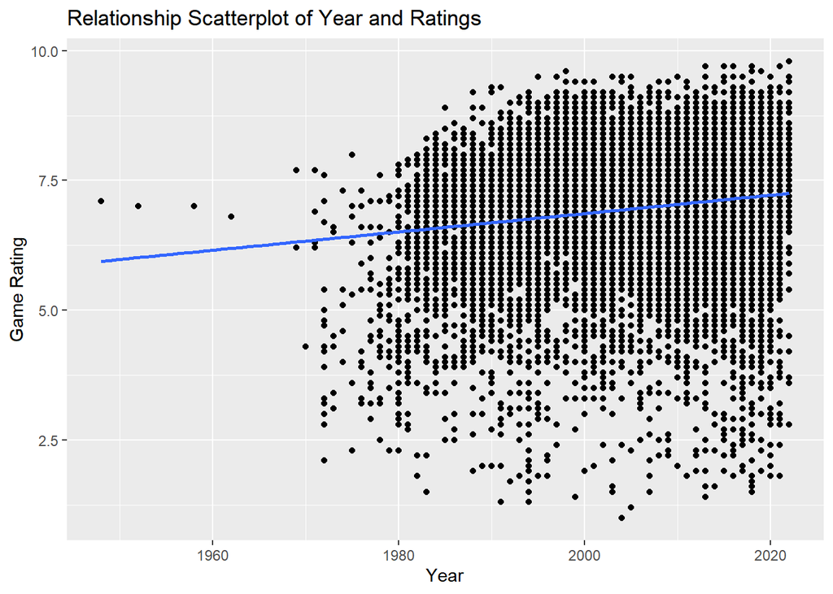

```r
#Graph
ggplot(game_fil_reg, aes(x = year, y = rating)) +
  geom_point() +
  labs(x = "Year",
       y = "Game Rating",
       title = "Relationship Scatterplot of Year and Ratings")+
        geom_smooth(method = "lm", se = FALSE)
```

```r
#Regression Table
# Fit regression model:
fit_model <- lm(year ~ rating, data = game_fil_reg)
# Get regression table:
get_regression_table(fit_model)
```

```
## # A tibble: 2 × 7
##   term      estimate std_error statistic p_value lower_ci upper_ci
##   <chr>        <dbl>     <dbl>     <dbl>   <dbl>    <dbl>    <dbl>
## 1 intercept  1995.       0.538    3710.        0  1994.    1997.
## 2 rating        1.32     0.076      17.3       0     1.17     1.47
```

```r
#R^2
summary(fit_model)
```

```
##
## Call:
## lm(formula = year ~ rating, data = game_fil_reg)
##
## Residuals:
##     Min      1Q  Median      3Q     Max
## -56.834  -8.020   0.507   9.166  23.149
##
## Coefficients:
##              Estimate Std. Error t value Pr(>|t|)
## (Intercept) 1995.4795     0.5379 3709.87   <2e-16 ***
## rating         1.3175     0.0762   17.29   <2e-16 ***
## ---
## Signif. codes:  0 '***' 0.001 '**' 0.01 '*' 0.05 '.' 0.1 ' ' 1
##
## Residual standard error: 10.71 on 12530 degrees of freedom
##   (103 observations deleted due to missingness)
## Multiple R-squared:  0.0233, Adjusted R-squared:  0.02322
## F-statistic: 298.9 on 1 and 12530 DF,  p-value: < 2.2e-16
```

### Conclusions

> Below, interpret the results of this analysis (that is, describe what the results mean for your data). Please also discuss any practical implications of these results (that is, explain how people might wish to think or act differently based on these results). [2 points]